# GA_HW11_Data605

Gabe Abreu

11/7/2020

## Data 605 HW11

Using the “cars” dataset in R, build a linear model for stopping distance as a function of speed and replicate the analysis of your textbook chapter 3 (visualization, quality evaluation of the model, and residual analysis.)

```r
#Load the cars dataset into a variable as a data frame
cars <- datasets::cars


#Let's investigate the data
summary(cars)
```

```
##      speed           dist
##  Min.   : 4.0   Min.   :  2.00
##  1st Qu.:12.0   1st Qu.: 26.00
##  Median :15.0   Median : 36.00
##  Mean   :15.4   Mean   : 42.98
##  3rd Qu.:19.0   3rd Qu.: 56.00
##  Max.   :25.0   Max.   :120.00
```

```r
describe(cars)
```

```
##       vars  n  mean    sd median trimmed   mad min max range  skew kurtosis
## speed    1 50 15.40  5.29     15   15.47  5.93   4  25    21 -0.11    -0.67
## dist     2 50 42.98 25.77     36   40.88 23.72   2 120   118  0.76     0.12
##         se
## speed 0.75
## dist  3.64
```

```r
#Using the lm formula to build the linear regression model
cars.lm <- lm(dist ~ speed, data=cars)

#The summary will give us coefficients as well the slope and intercept that can be used to build the linear regression model evaluating the relationship between distance and speed.
summary(cars.lm)
```

```
##
## Call:
## lm(formula = dist ~ speed, data = cars)
##
## Residuals:
##     Min      1Q  Median      3Q     Max
## -29.069  -9.525  -2.272   9.215  43.201
##
## Coefficients:
##             Estimate Std. Error t value Pr(>|t|)
## (Intercept) -17.5791     6.7584  -2.601   0.0123 *
## speed         3.9324     0.4155   9.464 1.49e-12 ***
## ---
## Signif. codes:  0 '***' 0.001 '**' 0.01 '*' 0.05 '.' 0.1 ' ' 1
##
## Residual standard error: 15.38 on 48 degrees of freedom
## Multiple R-squared:  0.6511, Adjusted R-squared:  0.6438
## F-statistic: 89.57 on 1 and 48 DF,  p-value: 1.49e-12
```

What’s important to take note is the p value which is less than 0.05, making it statistically significant. The intercept is -17.5791 and the slope is 3.9324, meaning the distance changes by 3.9324 per changes in speed.

The adjusted R^2 is 0.6438.

## Visualizing the Data

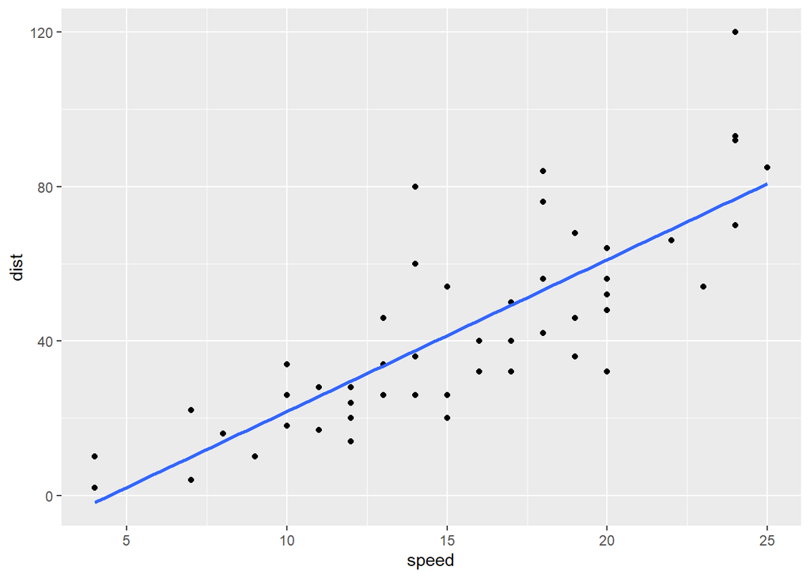

```r
#ggplot without getting the slope and intercept manually
ggplot(data = cars, aes(x = speed, y = dist)) +
  geom_point() +
  stat_smooth(method = "lm", se = FALSE)
```

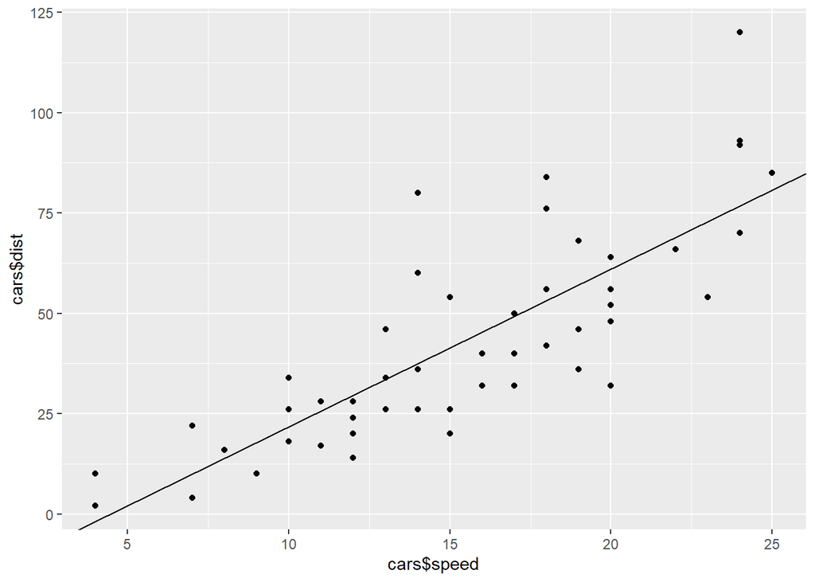

```r
#ggplot with slope and intercept gotten from cars.lm

mx <- coef(cars.lm)[1]
slope <- coef(cars.lm)[2]

ggplot(cars.lm, aes(cars$speed, cars$dist)) +
  geom_point() +
  geom_abline(slope = slope, intercept = mx, show.legend = TRUE)
```